# 单变量绘图选择

# 双变量绘图选择

首先看一下各个变量之间的相关系数

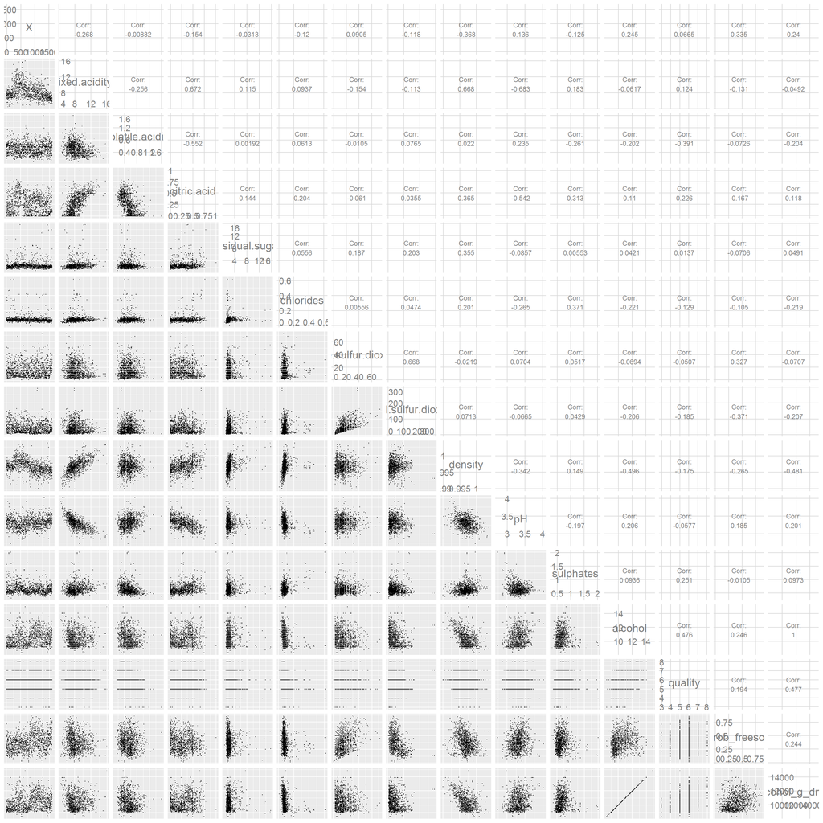

其中alcohol,alcohol_g_dm3,sulphates,citric.acid,prob_freeso2与quality是相对正相关关系,从以下散点图和summary的数据中可以看出验证.

```
##  [1] "X"                    "fixed.acidity"        "volatile.acidity"
##  [4] "citric.acid"          "residual.sugar"       "chlorides"
##  [7] "free.sulfur.dioxide"  "total.sulfur.dioxide" "density"
## [10] "pH"                   "sulphates"            "alcohol"
## [13] "quality"              "prob_freeso2"         "alcohol_g_dm3"
```

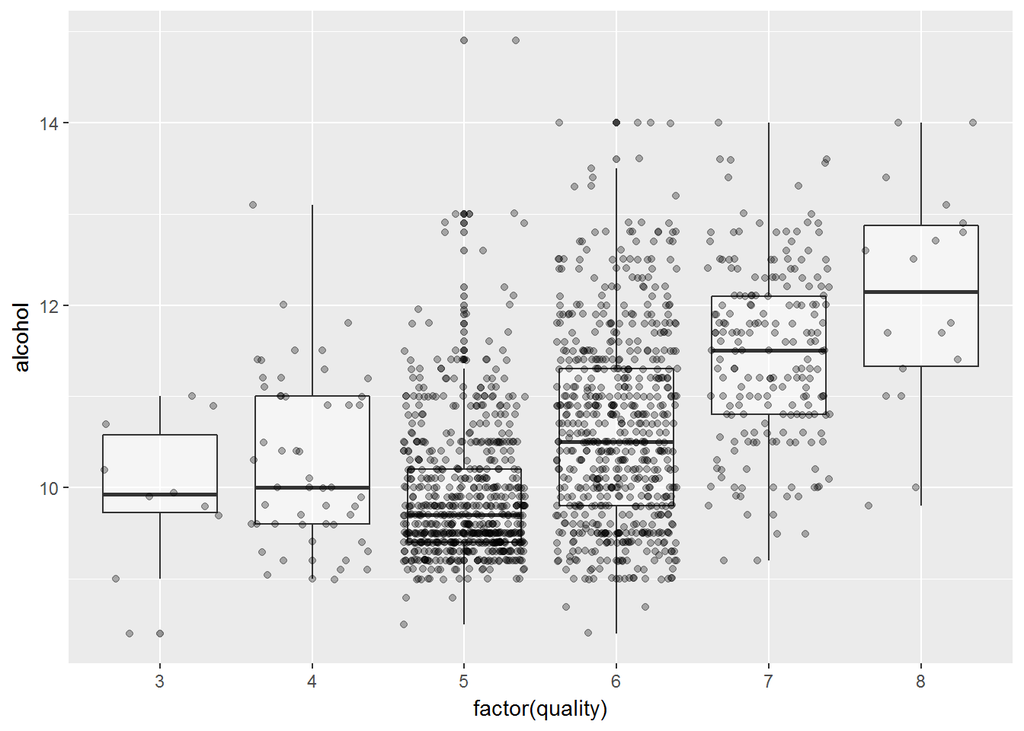

```
## winequality$quality: 3
##    Min. 1st Qu.  Median    Mean 3rd Qu.    Max.
##   8.400   9.725   9.925   9.955  10.575  11.000
## --------------------------------------------------------
## winequality$quality: 4
##    Min. 1st Qu.  Median    Mean 3rd Qu.    Max.
##    9.00    9.60   10.00   10.27   11.00   13.10
## --------------------------------------------------------
## winequality$quality: 5
##    Min. 1st Qu.  Median    Mean 3rd Qu.    Max.
##     8.5     9.4     9.7     9.9    10.2    14.9
## --------------------------------------------------------
## winequality$quality: 6
##    Min. 1st Qu.  Median    Mean 3rd Qu.    Max.
##    8.40    9.80   10.50   10.63   11.30   14.00
## --------------------------------------------------------
## winequality$quality: 7
##    Min. 1st Qu.  Median    Mean 3rd Qu.    Max.
##    9.20   10.80   11.50   11.47   12.10   14.00
## --------------------------------------------------------
## winequality$quality: 8
##    Min. 1st Qu.  Median    Mean 3rd Qu.    Max.
##    9.80   11.32   12.15   12.09   12.88   14.00
```

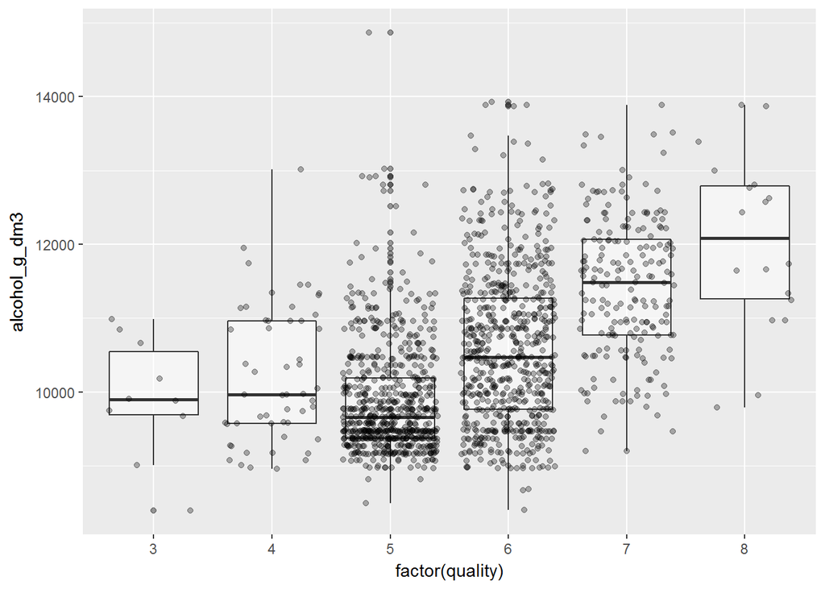

```
## winequality$quality: 3
##    Min. 1st Qu.  Median    Mean 3rd Qu.    Max.
##    8395    9691    9897    9929   10543   10988
## --------------------------------------------------------
## winequality$quality: 4
##    Min. 1st Qu.  Median    Mean 3rd Qu.    Max.
##    8960    9573    9966   10229   10965   13014
## --------------------------------------------------------
## winequality$quality: 5
##    Min. 1st Qu.  Median    Mean 3rd Qu.    Max.
##    8493    9378    9658    9871   10188   14864
## --------------------------------------------------------
## winequality$quality: 6
##    Min. 1st Qu.  Median    Mean 3rd Qu.    Max.
##    8407    9762   10471   10592   11268   13926
## --------------------------------------------------------
## winequality$quality: 7
##    Min. 1st Qu.  Median    Mean 3rd Qu.    Max.
##    9200   10773   11487   11420   12063   13882
## --------------------------------------------------------
## winequality$quality: 8
##    Min. 1st Qu.  Median    Mean 3rd Qu.    Max.
##    9787   11264   12084   12035   12793   13884
```

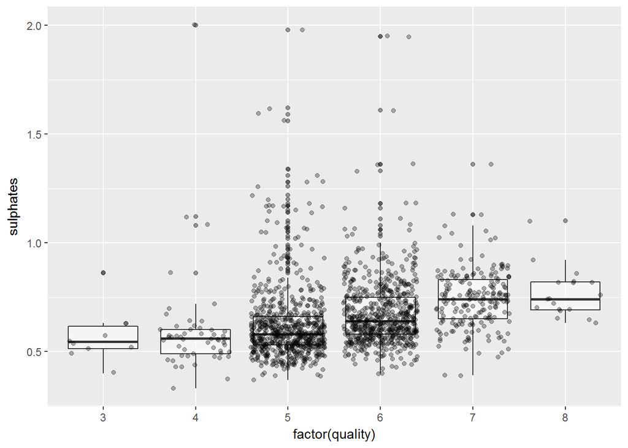

```
## winequality$quality: 3
##    Min. 1st Qu.  Median    Mean 3rd Qu.    Max.
##  0.4000  0.5125  0.5450  0.5700  0.6150  0.8600
## --------------------------------------------------------
## winequality$quality: 4
##    Min. 1st Qu.  Median    Mean 3rd Qu.    Max.
##  0.3300  0.4900  0.5600  0.5964  0.6000  2.0000
## --------------------------------------------------------
## winequality$quality: 5
##    Min. 1st Qu.  Median    Mean 3rd Qu.    Max.
##   0.370   0.530   0.580   0.621   0.660   1.980
## --------------------------------------------------------
## winequality$quality: 6
##    Min. 1st Qu.  Median    Mean 3rd Qu.    Max.
##  0.4000  0.5800  0.6400  0.6753  0.7500  1.9500
## --------------------------------------------------------
## winequality$quality: 7
##    Min. 1st Qu.  Median    Mean 3rd Qu.    Max.
##  0.3900  0.6500  0.7400  0.7413  0.8300  1.3600
## --------------------------------------------------------
## winequality$quality: 8
##    Min. 1st Qu.  Median    Mean 3rd Qu.    Max.
##  0.6300  0.6900  0.7400  0.7678  0.8200  1.1000
```

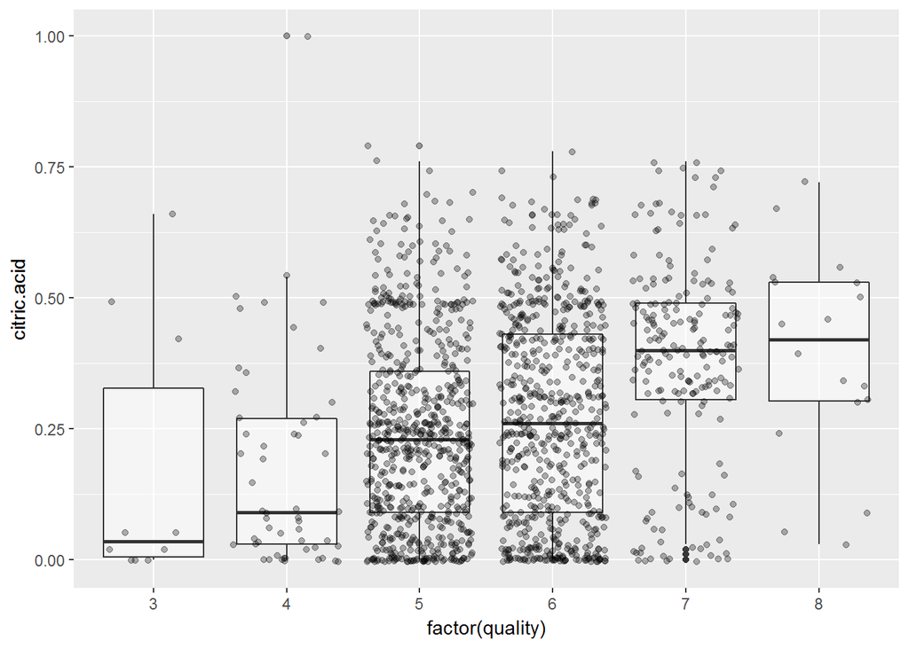

```
## winequality$quality: 3
##    Min. 1st Qu.  Median    Mean 3rd Qu.    Max.
##  0.0000  0.0050  0.0350  0.1710  0.3275  0.6600
## --------------------------------------------------------
## winequality$quality: 4
##    Min. 1st Qu.  Median    Mean 3rd Qu.    Max.
##  0.0000  0.0300  0.0900  0.1742  0.2700  1.0000
## --------------------------------------------------------
## winequality$quality: 5
##    Min. 1st Qu.  Median    Mean 3rd Qu.    Max.
##  0.0000  0.0900  0.2300  0.2437  0.3600  0.7900
## --------------------------------------------------------
## winequality$quality: 6
##    Min. 1st Qu.  Median    Mean 3rd Qu.    Max.
##  0.0000  0.0900  0.2600  0.2738  0.4300  0.7800
## --------------------------------------------------------
## winequality$quality: 7
##    Min. 1st Qu.  Median    Mean 3rd Qu.    Max.
##  0.0000  0.3050  0.4000  0.3752  0.4900  0.7600
## --------------------------------------------------------
## winequality$quality: 8
##    Min. 1st Qu.  Median    Mean 3rd Qu.    Max.
##  0.0300  0.3025  0.4200  0.3911  0.5300  0.7200
```

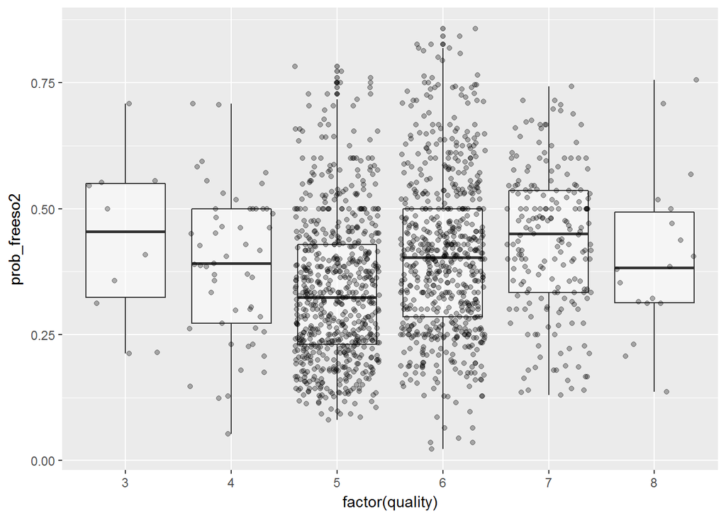

```
## winequality$quality: 3
##    Min. 1st Qu.  Median    Mean 3rd Qu.    Max.
##  0.2128  0.3237  0.4541  0.4366  0.5502  0.7083
## --------------------------------------------------------
## winequality$quality: 4
##    Min. 1st Qu.  Median    Mean 3rd Qu.    Max.
##  0.0531  0.2727  0.3913  0.3875  0.5000  0.7083
## --------------------------------------------------------
## winequality$quality: 5
##    Min. 1st Qu.  Median    Mean 3rd Qu.    Max.
## 0.08065 0.23077 0.32394 0.33917 0.42857 0.78261
## --------------------------------------------------------
## winequality$quality: 6
##    Min. 1st Qu.  Median    Mean 3rd Qu.    Max.
## 0.02273 0.28571 0.40362 0.40962 0.50000 0.85714
## --------------------------------------------------------
## winequality$quality: 7
##    Min. 1st Qu.  Median    Mean 3rd Qu.    Max.
##  0.1298  0.3333  0.4500  0.4361  0.5357  0.7429
## --------------------------------------------------------
## winequality$quality: 8
##    Min. 1st Qu.  Median    Mean 3rd Qu.    Max.
##  0.1364  0.3133  0.3823  0.4065  0.4926  0.7556
```

另外，volatile.acidity,total.sulfur.dioxide,density,chlorides等变量则与quliaty呈现负相关关系，以下散点图和summary能验证。

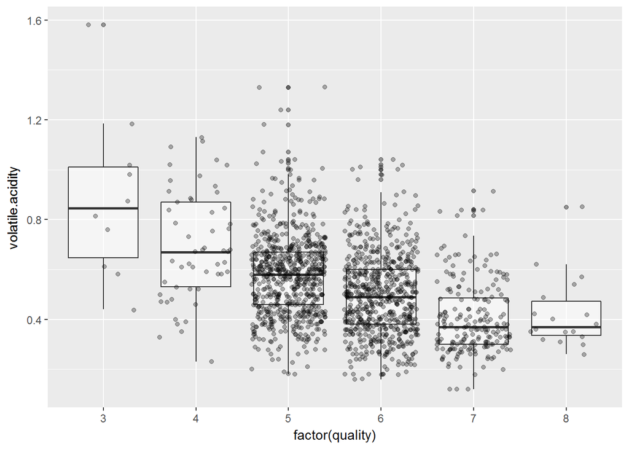

```
## winequality$quality: 3
##    Min. 1st Qu.  Median    Mean 3rd Qu.    Max.
##  0.4400  0.6475  0.8450  0.8845  1.0100  1.5800
## --------------------------------------------------------
## winequality$quality: 4
##    Min. 1st Qu.  Median    Mean 3rd Qu.    Max.
##   0.230   0.530   0.670   0.694   0.870   1.130
## --------------------------------------------------------
## winequality$quality: 5
##    Min. 1st Qu.  Median    Mean 3rd Qu.    Max.
##   0.180   0.460   0.580   0.577   0.670   1.330
## --------------------------------------------------------
## winequality$quality: 6
##    Min. 1st Qu.  Median    Mean 3rd Qu.    Max.
##  0.1600  0.3800  0.4900  0.4975  0.6000  1.0400
## --------------------------------------------------------
## winequality$quality: 7
##    Min. 1st Qu.  Median    Mean 3rd Qu.    Max.
##  0.1200  0.3000  0.3700  0.4039  0.4850  0.9150
## --------------------------------------------------------
## winequality$quality: 8
##    Min. 1st Qu.  Median    Mean 3rd Qu.    Max.
##  0.2600  0.3350  0.3700  0.4233  0.4725  0.8500
```

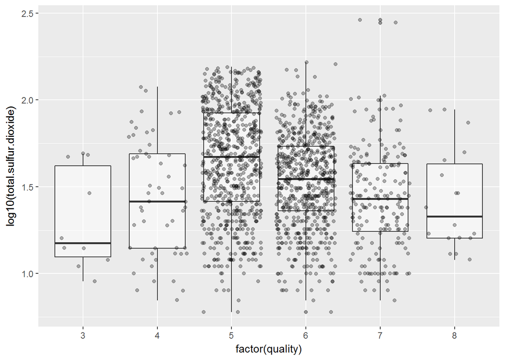

```
## winequality$quality: 3
##    Min. 1st Qu.  Median    Mean 3rd Qu.    Max.
##     9.0    12.5    15.0    24.9    42.5    49.0
## --------------------------------------------------------
## winequality$quality: 4
##    Min. 1st Qu.  Median    Mean 3rd Qu.    Max.
##    7.00   14.00   26.00   36.25   49.00  119.00
## --------------------------------------------------------
## winequality$quality: 5
##    Min. 1st Qu.  Median    Mean 3rd Qu.    Max.
##    6.00   26.00   47.00   56.51   84.00  155.00
## --------------------------------------------------------
## winequality$quality: 6
##    Min. 1st Qu.  Median    Mean 3rd Qu.    Max.
##    6.00   23.00   35.00   40.87   54.00  165.00
## --------------------------------------------------------
## winequality$quality: 7
##    Min. 1st Qu.  Median    Mean 3rd Qu.    Max.
##    7.00   17.50   27.00   35.02   43.00  289.00
## --------------------------------------------------------
## winequality$quality: 8
##    Min. 1st Qu.  Median    Mean 3rd Qu.    Max.
##   12.00   16.00   21.50   33.44   43.00   88.00
```

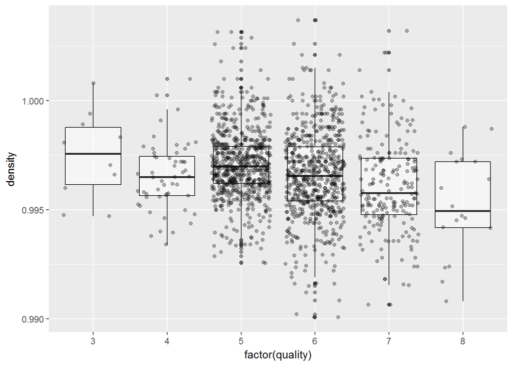

```
## winequality$quality: 3
##    Min. 1st Qu.  Median    Mean 3rd Qu.    Max.
##  0.9947  0.9961  0.9976  0.9975  0.9988  1.0008
## --------------------------------------------------------
## winequality$quality: 4
##    Min. 1st Qu.  Median    Mean 3rd Qu.    Max.
##  0.9934  0.9957  0.9965  0.9965  0.9974  1.0010
## --------------------------------------------------------
## winequality$quality: 5
##    Min. 1st Qu.  Median    Mean 3rd Qu.    Max.
##  0.9926  0.9962  0.9970  0.9971  0.9979  1.0031
## --------------------------------------------------------
## winequality$quality: 6
##    Min. 1st Qu.  Median    Mean 3rd Qu.    Max.
##  0.9901  0.9954  0.9966  0.9966  0.9979  1.0037
## --------------------------------------------------------
## winequality$quality: 7
##    Min. 1st Qu.  Median    Mean 3rd Qu.    Max.
##  0.9906  0.9948  0.9958  0.9961  0.9974  1.0032
## --------------------------------------------------------
## winequality$quality: 8
##    Min. 1st Qu.  Median    Mean 3rd Qu.    Max.
##  0.9908  0.9942  0.9949  0.9952  0.9972  0.9988
```

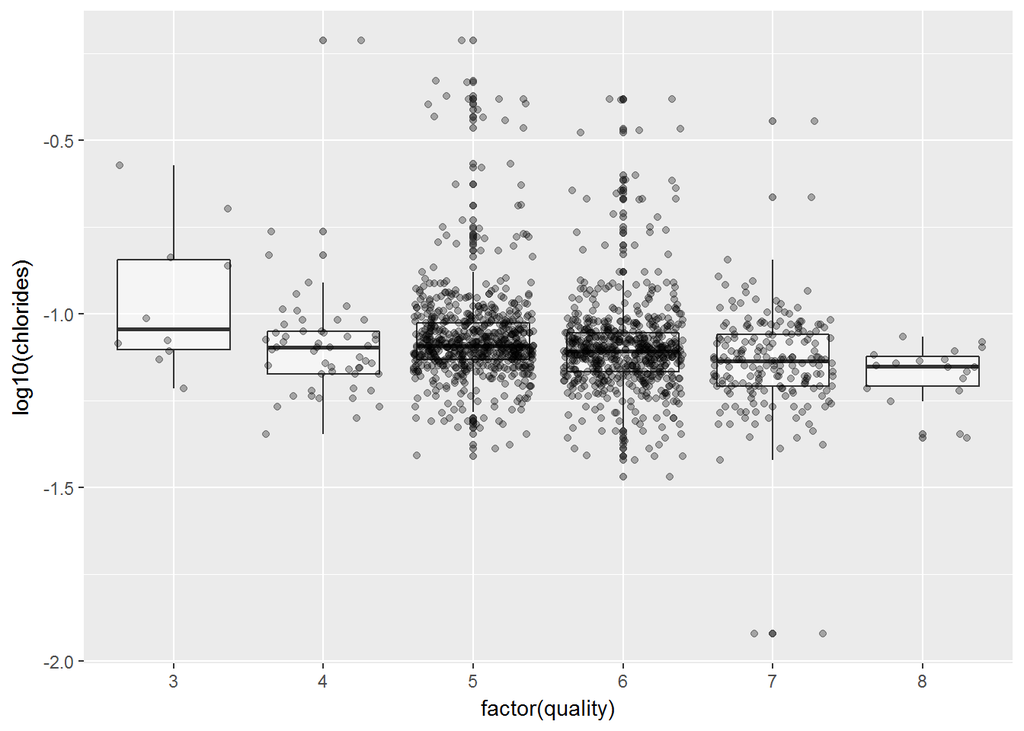

```
## winequality$quality: 3
##    Min. 1st Qu.  Median    Mean 3rd Qu.    Max.
##  0.0610  0.0790  0.0905  0.1225  0.1430  0.2670
## --------------------------------------------------------
## winequality$quality: 4
##    Min. 1st Qu.  Median    Mean 3rd Qu.    Max.
## 0.04500 0.06700 0.08000 0.09068 0.08900 0.61000
## --------------------------------------------------------
## winequality$quality: 5
##    Min. 1st Qu.  Median    Mean 3rd Qu.    Max.
## 0.03900 0.07400 0.08100 0.09274 0.09400 0.61100
## --------------------------------------------------------
## winequality$quality: 6
##    Min. 1st Qu.  Median    Mean 3rd Qu.    Max.
## 0.03400 0.06825 0.07800 0.08496 0.08800 0.41500
## --------------------------------------------------------
## winequality$quality: 7
##    Min. 1st Qu.  Median    Mean 3rd Qu.    Max.
## 0.01200 0.06200 0.07300 0.07659 0.08700 0.35800
## --------------------------------------------------------
## winequality$quality: 8
##    Min. 1st Qu.  Median    Mean 3rd Qu.    Max.
## 0.04400 0.06200 0.07050 0.06844 0.07550 0.08600
```

无论是正还是负相关，alcohol,prob_freeso2，total.sulfur.dioxide与quality的关系都在中间出现一个最高(低)值，猜测可能与数据源中quality分布不均衡有关

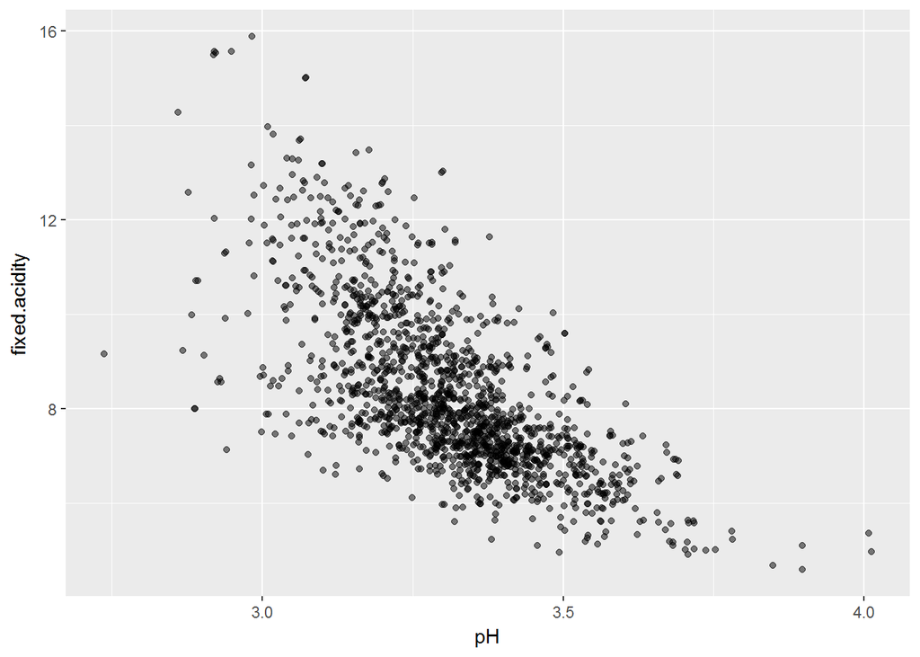

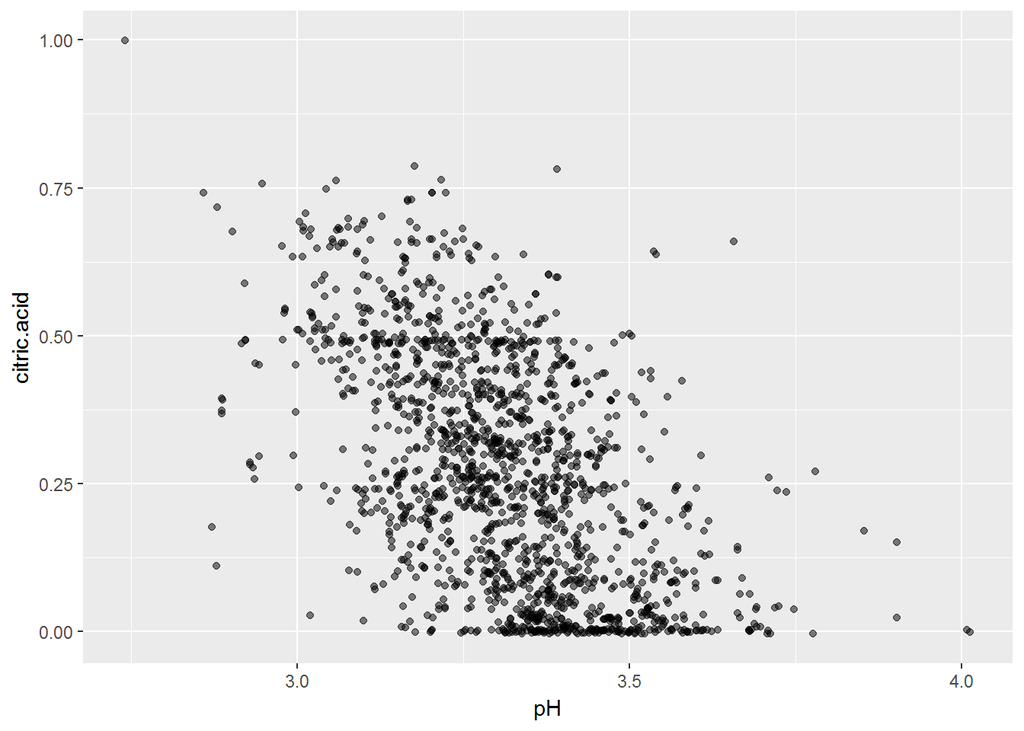

可以看出pH值与fixed.acidity，citric.acid都有相对线性关系

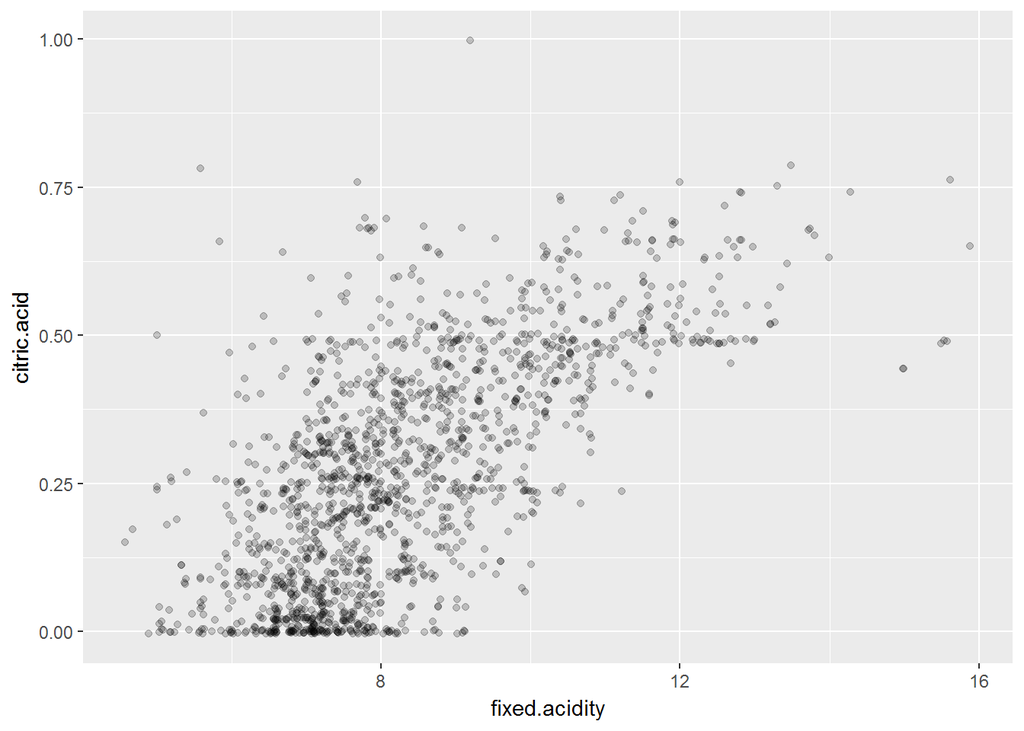

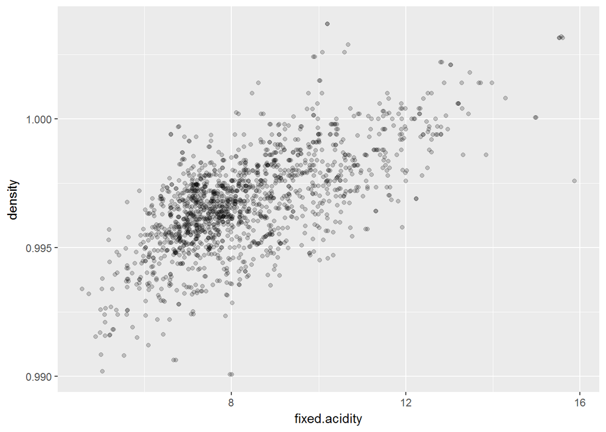

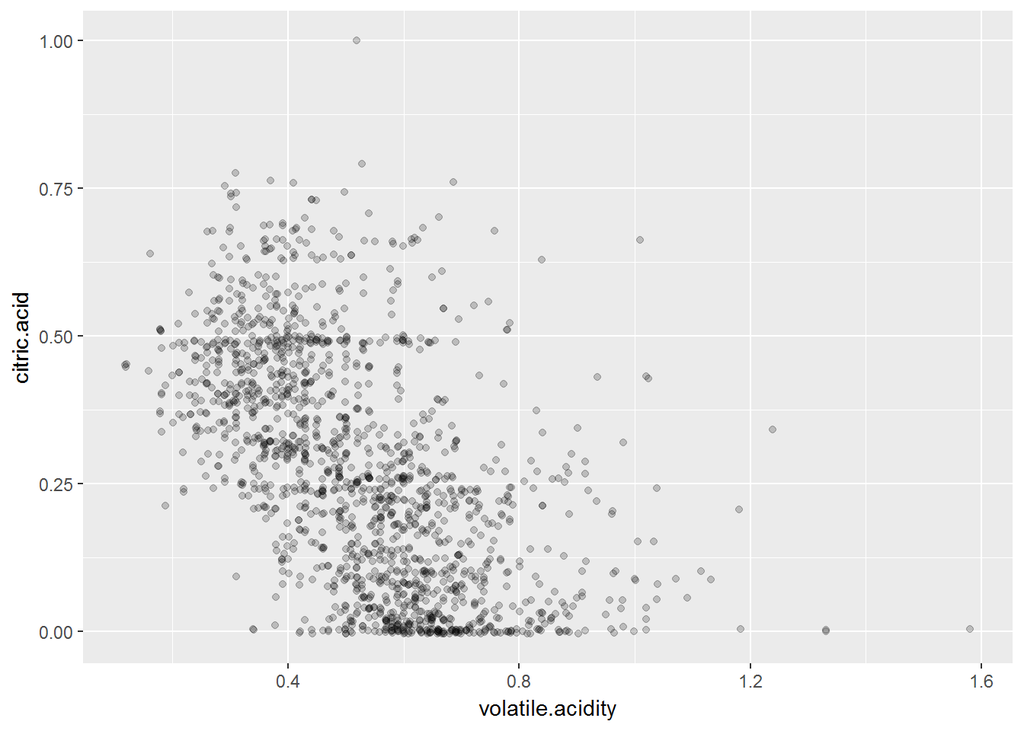

可以看出以上fixed.acidity与density之间，fixed.acidity与citric.acid之间的线性关系相对较强,volatile.acidity与citric.acid呈现负相关，其余为正相关

从之前的分析可以看出alcohol对quality的影响相对较大，来尝试拟合一下二者的线性关系

```
##
## Calls:
## m1: lm(formula = quality ~ alcohol_g_dm3, data = winequality)
##
## ================================
##   (Intercept)         1.829***
##                      (0.176)
##   alcohol_g_dm3       0.000***
##                      (0.000)
## --------------------------------
##   R-squared           0.228
##   adj. R-squared      0.227
##   sigma               0.710
##   F                 471.002
##   p                   0.000
##   Log-likelihood  -1719.999
##   Deviance          804.805
##   AIC              3445.998
##   BIC              3462.129
##   N                1599
## ================================
```

```
## 'data.frame':    1599 obs. of  15 variables:
##  $ X                   : int  1 2 3 4 5 6 7 8 9 10 ...
##  $ fixed.acidity       : num  7.4 7.8 7.8 11.2 7.4 7.4 7.9 7.3 7.8 7.5 ...
##  $ volatile.acidity    : num  0.7 0.88 0.76 0.28 0.7 0.66 0.6 0.65 0.58 0.5 ...
##  $ citric.acid         : num  0 0 0.04 0.56 0 0 0.06 0 0.02 0.36 ...
##  $ residual.sugar      : num  1.9 2.6 2.3 1.9 1.9 1.8 1.6 1.2 2 6.1 ...
##  $ chlorides           : num  0.076 0.098 0.092 0.075 0.076 0.075 0.069 0.065 0.073 0.071 ...
##  $ free.sulfur.dioxide : num  11 25 15 17 11 13 15 15 9 17 ...
##  $ total.sulfur.dioxide: num  34 67 54 60 34 40 59 21 18 102 ...
##  $ density             : num  0.998 0.997 0.997 0.998 0.998 ...
##  $ pH                  : num  3.51 3.2 3.26 3.16 3.51 3.51 3.3 3.39 3.36 3.35 ...
##  $ sulphates           : num  0.56 0.68 0.65 0.58 0.56 0.56 0.46 0.47 0.57 0.8 ...
##  $ alcohol             : num  9.4 9.8 9.8 9.8 9.4 9.4 9.4 10 9.5 10.5 ...
##  $ quality             : int  5 5 5 6 5 5 5 7 7 5 ...
##  $ prob_freeso2        : num  0.324 0.373 0.278 0.283 0.324 ...
##  $ alcohol_g_dm3       : num  9379 9769 9771 9780 9379 ...
```

结果R^2只有0.227，不是很理想，可能还需要再加入其他因素

# 双变量分析

### 你发现最强的关系是什么？

alcohol与quality的关系是相对较强的，随着alcohol的增加，quality也随着增加

# 多变量绘图选择

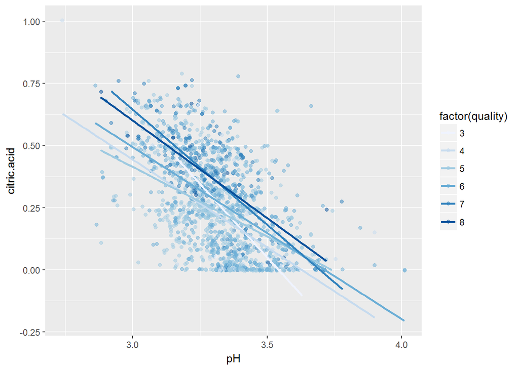

在线性负相关的前提下，quality越高，citric.acid越高，ph越低

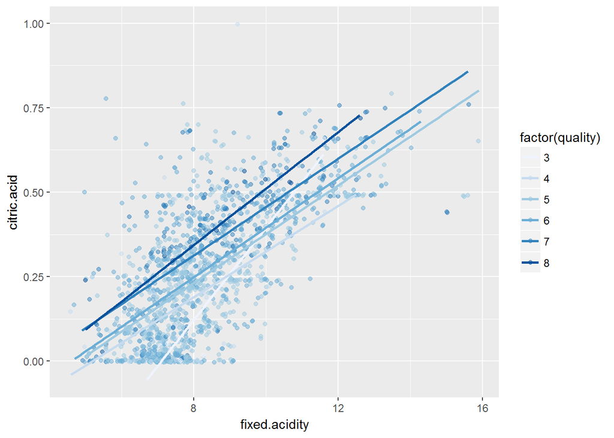

在线性正相关的前提下，quality越高，citric.acid越高，fixed.acidity越高

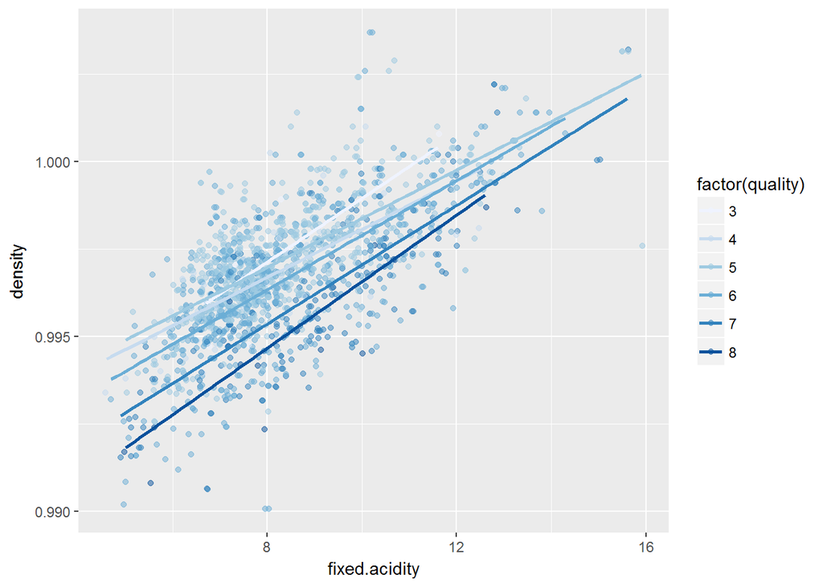

在线性正相关的前提下，quality越高，fixed.acidity越低，density越低

```
##
## Calls:
## m1: lm(formula = quality ~ alcohol_g_dm3, data = winequality)
## m2: lm(formula = quality ~ alcohol_g_dm3 + sulphates, data = winequality)
## m3: lm(formula = quality ~ alcohol_g_dm3 + sulphates + citric.acid,
##     data = winequality)
## m4: lm(formula = quality ~ alcohol_g_dm3 + sulphates + citric.acid +
##     prob_freeso2, data = winequality)
## m5: lm(formula = quality ~ alcohol_g_dm3 + sulphates + citric.acid +
##     prob_freeso2 + volatile.acidity, data = winequality)
## m6: lm(formula = quality ~ alcohol_g_dm3 + sulphates + citric.acid +
##     prob_freeso2 + volatile.acidity + I(log(total.sulfur.dioxide)),
##     data = winequality)
## m7: lm(formula = quality ~ alcohol_g_dm3 + sulphates + citric.acid +
##     prob_freeso2 + volatile.acidity + I(log(total.sulfur.dioxide)) +
##     density, data = winequality)
## m8: lm(formula = quality ~ alcohol_g_dm3 + sulphates + citric.acid +
##     prob_freeso2 + volatile.acidity + I(log(total.sulfur.dioxide)) +
##     density + I(log(chlorides)), data = winequality)
##
## ================================================================================================================================================
##                                      m1            m2            m3            m4            m5            m6            m7            m8
## ------------------------------------------------------------------------------------------------------------------------------------------------
##   (Intercept)                       1.829***      1.340***      1.405***      1.403***      2.553***      2.847***     -9.454       -13.423
##                                    (0.176)       (0.179)       (0.178)       (0.176)       (0.202)       (0.237)      (11.828)      (11.834)
##   alcohol_g_dm3                     0.000***      0.000***      0.000***      0.000***      0.000***      0.000***      0.000***      0.000***
##                                    (0.000)       (0.000)       (0.000)       (0.000)       (0.000)       (0.000)       (0.000)       (0.000)
##   sulphates                                       0.986***      0.811***      0.795***      0.687***      0.713***      0.699***      0.817***
##                                                  (0.102)       (0.107)       (0.106)       (0.103)       (0.103)       (0.104)       (0.108)
##   citric.acid                                                   0.499***      0.601***      0.006        -0.006        -0.066         0.015
##                                                                (0.093)       (0.094)       (0.107)       (0.107)       (0.122)       (0.123)
##   prob_freeso2                                                                0.621***      0.427***      0.349**       0.358**       0.358**
##                                                                              (0.116)       (0.113)       (0.118)       (0.118)       (0.117)
##   volatile.acidity                                                                         -1.204***     -1.200***     -1.230***     -1.130***
##                                                                                            (0.114)       (0.113)       (0.117)       (0.120)
##   I(log(total.sulfur.dioxide))                                                                           -0.059*       -0.058*       -0.061*
##                                                                                                          (0.025)       (0.025)       (0.025)
##   density                                                                                                              12.258        15.752
##                                                                                                                       (11.784)      (11.779)
##   I(log(chlorides))                                                                                                                  -0.211***
##                                                                                                                                      (0.058)
## ------------------------------------------------------------------------------------------------------------------------------------------------
##   R-squared                         0.228         0.270         0.283         0.296         0.342         0.345         0.345         0.350
##   adj. R-squared                    0.227         0.269         0.282         0.294         0.340         0.342         0.342         0.347
##   sigma                             0.710         0.690         0.684         0.678         0.656         0.655         0.655         0.653
##   F                               471.002       295.402       209.989       167.467       165.794       139.493       119.726       107.208
##   p                                 0.000         0.000         0.000         0.000         0.000         0.000         0.000         0.000
##   Log-likelihood                -1719.999     -1674.839     -1660.506     -1646.148     -1591.674     -1588.868     -1588.325     -1581.730
##   Deviance                        804.805       760.606       747.091       733.794       685.463       683.061       682.597       676.989
##   AIC                            3445.998      3357.678      3331.012      3304.295      3197.349      3193.737      3194.649      3183.460
##   BIC                            3462.129      3379.187      3357.898      3336.558      3234.989      3236.754      3243.044      3237.231
##   N                              1599          1599          1599          1599          1599          1599          1599          1599
## ================================================================================================================================================
```

最终拟合的R^2只有0.35，不是很理想，可见本数据集中的变量并不能很好拟合quality的线性模型 综上所述，虽然各成分都没有与quality比较强的线性关系，但各种成分之间的影响相对较大，如出pH值与fixed.acidity，PH与citric.acid，fixed.acidity与citric.acid，fixed.acidity与density,volatile.acidity与citric.acid